# Project4_Survival

Alexander Andreev

3/8/2021

# 1 Минипроект. Выживание

## 1.1 EDA

Загрузим изучаемые данные и выведем о них краткую сводку:

```
##   futime fustat     age resid.ds rx ecog.ps
## 1     59      1 72.3315        2  1       1
## 2    115      1 74.4932        2  1       1
## 3    156      1 66.4658        2  1       2
## 4    421      0 53.3644        2  2       1
## 5    431      1 50.3397        2  1       1
## 6    448      0 56.4301        1  1       2
```

```
## 'data.frame':    26 obs. of  6 variables:
##  $ futime  : num  59 115 156 421 431 448 464 475 477 563 ...
##  $ fustat  : num  1 1 1 0 1 0 1 1 0 1 ...
##  $ age     : num  72.3 74.5 66.5 53.4 50.3 ...
##  $ resid.ds: num  2 2 2 2 2 1 2 2 2 1 ...
##  $ rx      : num  1 1 1 2 1 1 2 2 1 2 ...
##  $ ecog.ps : num  1 1 2 1 1 2 2 2 1 2 ...
```

Построим несколько диаграм для составления краткого субъективного представления о данных:

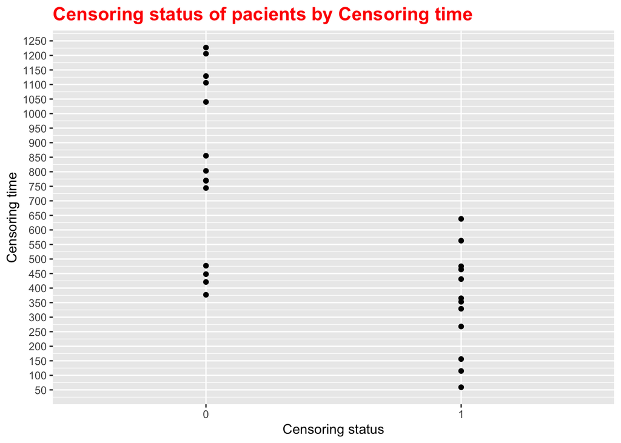

[figure not shown]

[figure not shown]

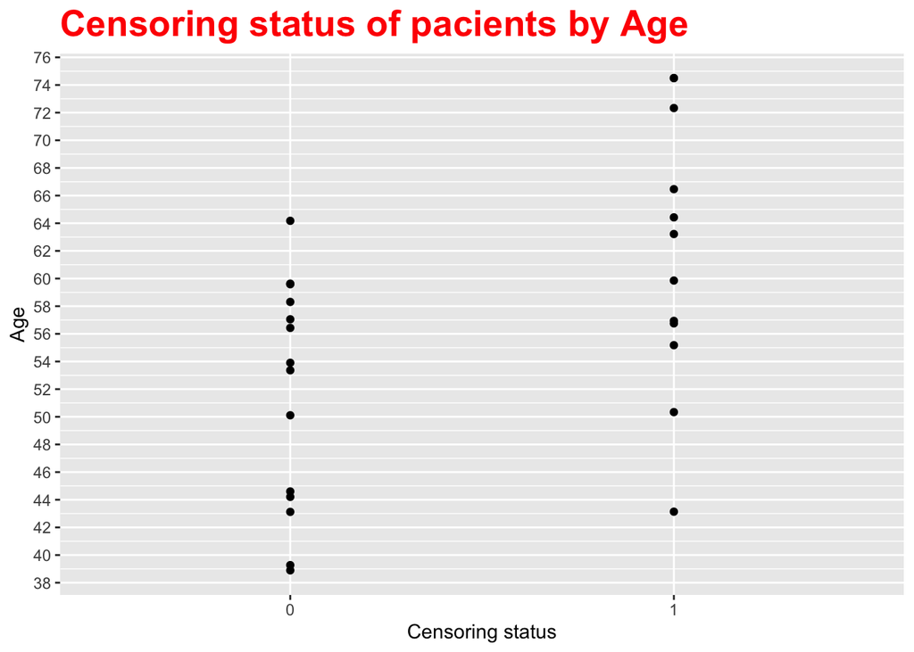

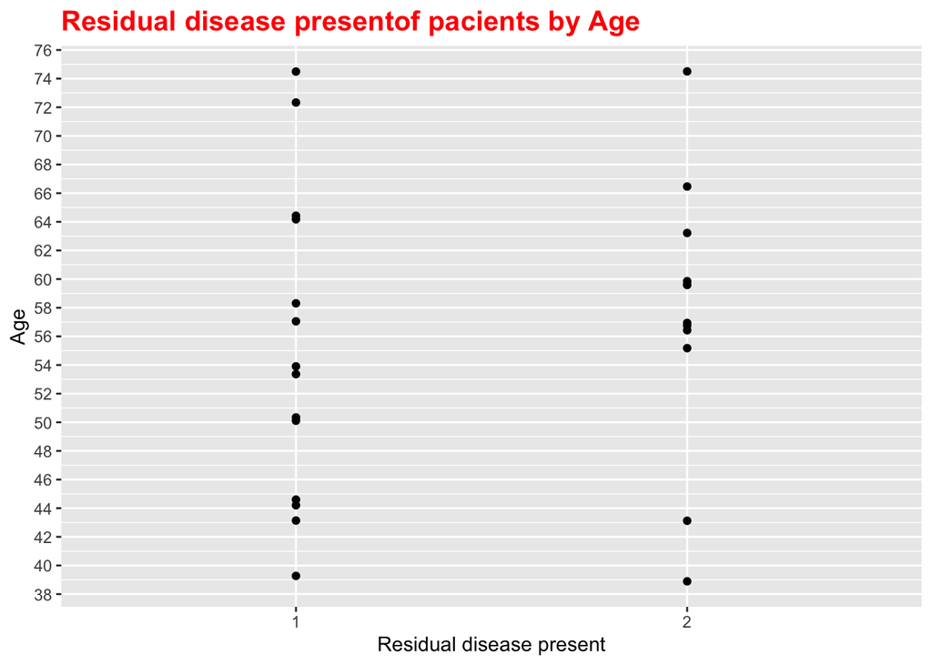

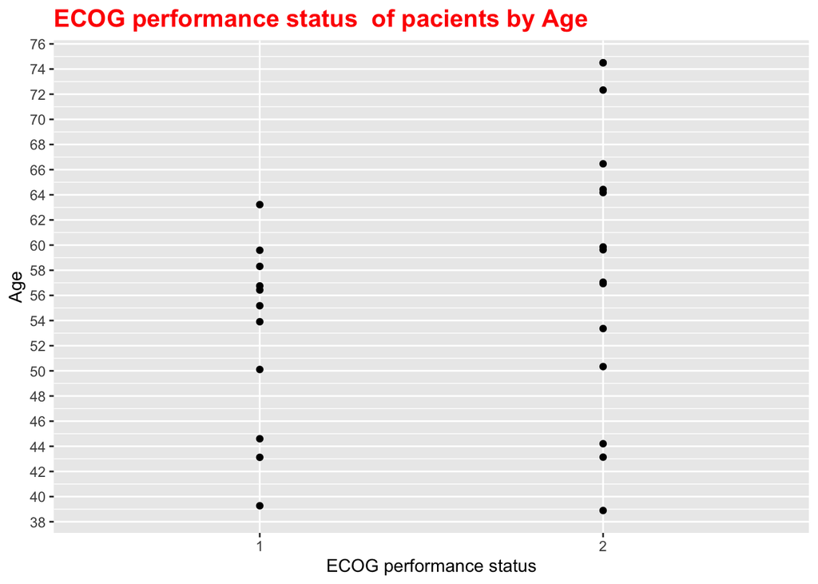

Также, если по оси y отложить возраст пациентов можно заметить, что самому младшиму пациенту около 39 лет, а самому старшему около 75 лет. К томуже, глядя на данные графики можно увидеть, что у более пожилых пациентов наблюдается наличие остаточных заболеваний после лечения и качество их жизни в дальнейшом ниже, чем у более молодых.

Следует отметить, что переменная Age является дискретной переменной, сдесь же она представленна как неприрывная. Таким образом для упрощения анализа данных было принято решение о превращении переменной Age в фактор. Для лучшего понимаю того, на какие группы следует разбивать данные выведем их частотную гистограмму.

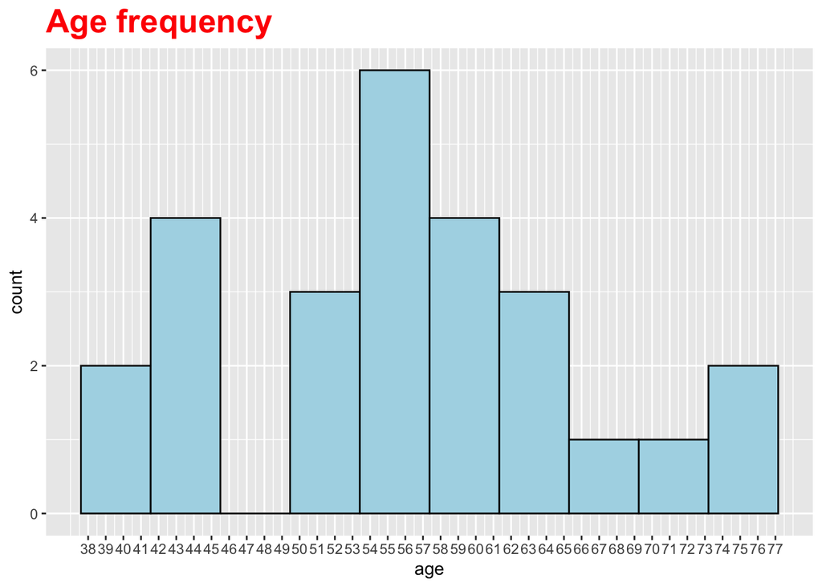

На графике видно разделение межу возрастными группами на границе в 50 лет. Тоесть, делим данные на 2 интервала [39,50) и [50,75].  
Аналогичным образом превратим переменные rx, resid.ds и ecog.ps в фактор и дадим названия уровням, чтобы в дальнейшем не запутаться с 0 и 1.

Выведем результат преобразования на экран:

```
##   futime fustat age resid.ds            rx ecog.ps age_group
## 1     59      1 old      yes  First_method    good       old
## 2    115      1 old      yes  First_method    good       old
## 3    156      1 old      yes  First_method     bad       old
## 4    421      0 old      yes Second_method    good       old
## 5    431      1 old      yes  First_method    good       old
## 6    448      0 old       no  First_method     bad       old
```

```
## 'data.frame':    26 obs. of  7 variables:
##  $ futime   : num  59 115 156 421 431 448 464 475 477 563 ...
##  $ fustat   : num  1 1 1 0 1 0 1 1 0 1 ...
##  $ age      : Factor w/ 2 levels "old","young": 1 1 1 1 1 1 1 1 1 1 ...
##  $ resid.ds : Factor w/ 2 levels "no","yes": 2 2 2 2 2 1 2 2 2 1 ...
##  $ rx       : Factor w/ 2 levels "First_method",..: 1 1 1 2 1 1 2 2 1 2 ...
##  $ ecog.ps  : Factor w/ 2 levels "good","bad": 1 1 2 1 1 2 2 2 1 2 ...
##  $ age_group: chr  "old" "old" "old" "old" ...
```

## 1.2 Кривые Каплана-Мейра и сравнение групп при помощи лонг - ранг тестов

Поскольку в первую очередь для исследования представляют интерес данные о выживаемость пациентов с течением времени, необходимо построить временную шкалу выживаемости:

```
##  [1]   59   115   156   421+  431   448+  464   475   477+  563   638   744+
## [13]  769+  770+  803+  855+ 1040+ 1106+ 1129+ 1206+ 1227+  268   329   353
## [25]  365   377+
```

Теперь можно построить линейную модель учитывающую изменение в выживаемости на основании факторов в зависимости от времени:

```
## Call: survfit(formula = surv_object ~ rx, data = data)
##
##                 rx=First_method
##  time n.risk n.event survival std.err lower 95% CI upper 95% CI
##    59     13       1    0.923  0.0739        0.789        1.000
##   115     12       1    0.846  0.1001        0.671        1.000
##   156     11       1    0.769  0.1169        0.571        1.000
##   268     10       1    0.692  0.1280        0.482        0.995
##   329      9       1    0.615  0.1349        0.400        0.946
##   431      8       1    0.538  0.1383        0.326        0.891
##   638      5       1    0.431  0.1467        0.221        0.840
##
##                 rx=Second_method
##  time n.risk n.event survival std.err lower 95% CI upper 95% CI
##   353     13       1    0.923  0.0739        0.789        1.000
##   365     12       1    0.846  0.1001        0.671        1.000
##   464      9       1    0.752  0.1256        0.542        1.000
##   475      8       1    0.658  0.1407        0.433        1.000
##   563      7       1    0.564  0.1488        0.336        0.946
```

Построим кривые Каплана - Мейра по полученной модели и применим лог-ранг тесты сравнения групп:

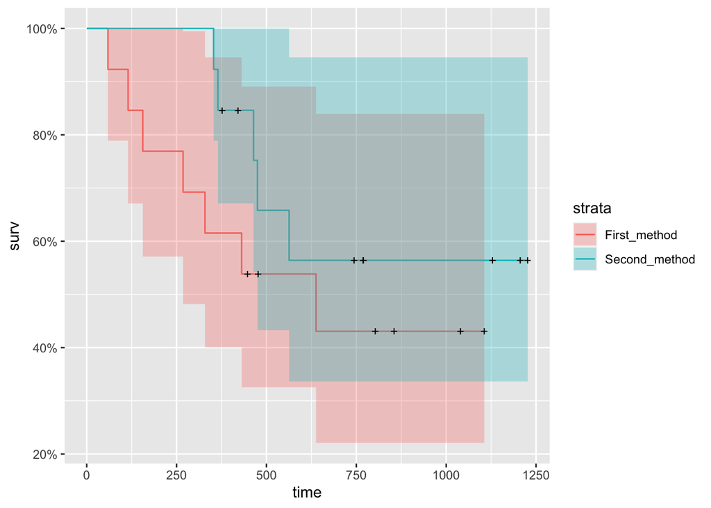

```
## Call:
## survdiff(formula = Surv(futime, fustat) ~ rx, data = data)
##
##                   N Observed Expected (O-E)^2/E (O-E)^2/V
## rx=First_method  13        7     5.23     0.596      1.06
## rx=Second_method 13        5     6.77     0.461      1.06
##
##  Chisq= 1.1  on 1 degrees of freedom, p= 0.3
```

Теперь построим такую же модель, только в зависимости от наличия остаточного заболевания у пациентов:

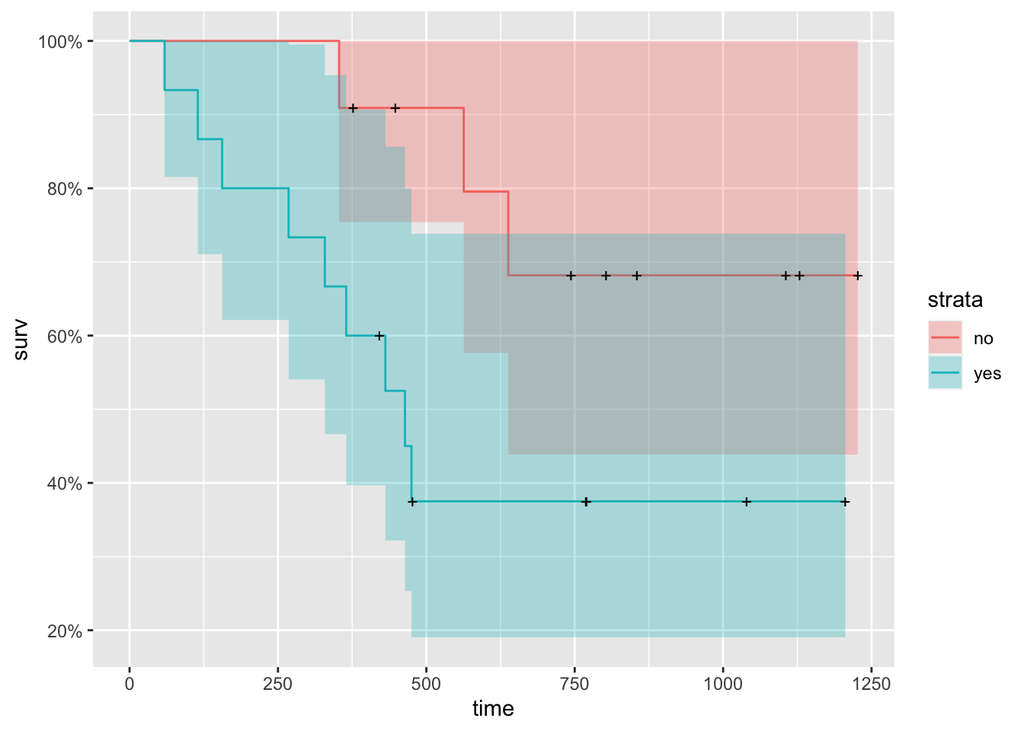

```
## Call:
## survdiff(formula = Surv(futime, fustat) ~ resid.ds, data = data)
##
##               N Observed Expected (O-E)^2/E (O-E)^2/V
## resid.ds=no  11        3     6.26      1.70      3.62
## resid.ds=yes 15        9     5.74      1.85      3.62
##
##  Chisq= 3.6  on 1 degrees of freedom, p= 0.06
```

Кривые расходятся рано и критерий лог-ранг теста почти значим.

Проведем точно такой же анализ для преременных age и ecog.ps.

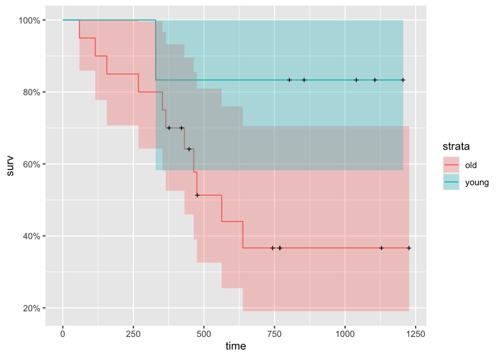

```
## Call:
## survdiff(formula = Surv(futime, fustat) ~ age_group, data = data)
##
##                  N Observed Expected (O-E)^2/E (O-E)^2/V
## age_group=old   20       11      8.4     0.804      2.75
## age_group=young  6        1      3.6     1.876      2.75
##
##  Chisq= 2.7  on 1 degrees of freedom, p= 0.1
```

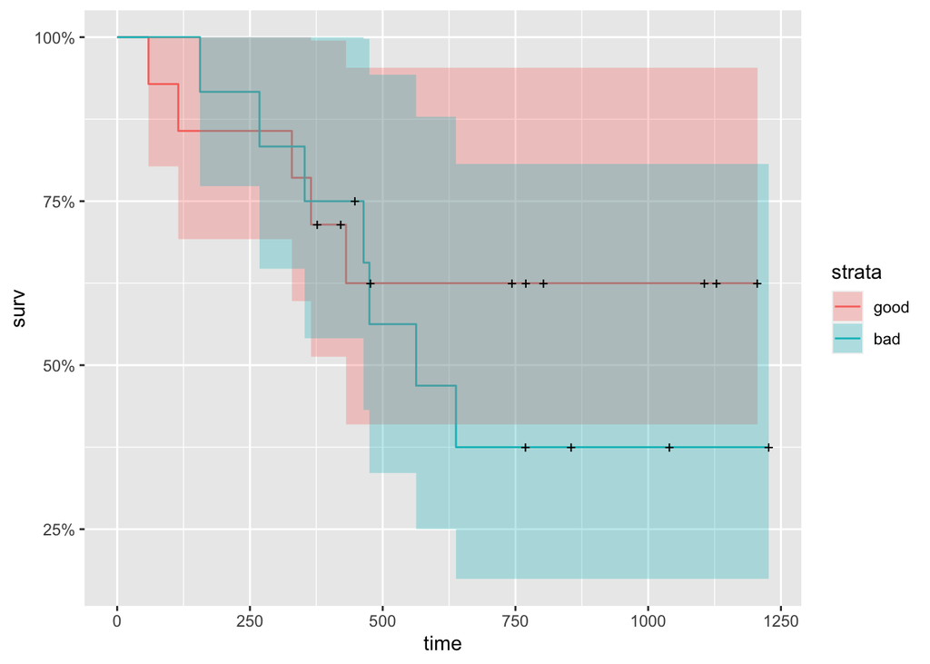

```
## Call:
## survdiff(formula = Surv(futime, fustat) ~ ecog.ps, data = data)
##
##               N Observed Expected (O-E)^2/E (O-E)^2/V
## ecog.ps=good 14        5     6.18     0.226     0.468
## ecog.ps=bad  12        7     5.82     0.240     0.468
##
##  Chisq= 0.5  on 1 degrees of freedom, p= 0.5
```

Значимого влияния возраста или ECOG на выживаемость не выявлено.

## 1.3 Оценка факторов влияющих на риск

Для более систематического взгляда на разные ковариаты применим модель Кокса. Построим модель пропорциональных опасностей Кокса:

```
## Call:
## coxph(formula = surv_object ~ rx + resid.ds + age_group + ecog.ps,
##     data = data)
##
##   n= 26, number of events= 12
##
##                    coef exp(coef) se(coef)      z Pr(>|z|)
## rxSecond_method -1.3814    0.2512   0.6448 -2.142   0.0322 *
## resid.dsyes      1.4470    4.2503   0.7292  1.984   0.0472 *
## age_groupyoung  -2.2013    0.1107   1.1069 -1.989   0.0467 *
## ecog.psbad       0.5859    1.7966   0.6329  0.926   0.3546
## ---
## Signif. codes:  0 '***' 0.001 '**' 0.01 '*' 0.05 '.' 0.1 ' ' 1
##
##                 exp(coef) exp(-coef) lower .95 upper .95
## rxSecond_method    0.2512     3.9803   0.07100    0.8891
## resid.dsyes        4.2503     0.2353   1.01801   17.7453
## age_groupyoung     0.1107     9.0368   0.01264    0.9686
## ecog.psbad         1.7966     0.5566   0.51966    6.2113
##
## Concordance= 0.782  (se = 0.065 )
## Likelihood ratio test= 12.19  on 4 df,   p=0.02
## Wald test            = 9.02  on 4 df,   p=0.06
## Score (logrank) test = 11.97  on 4 df,   p=0.02
```

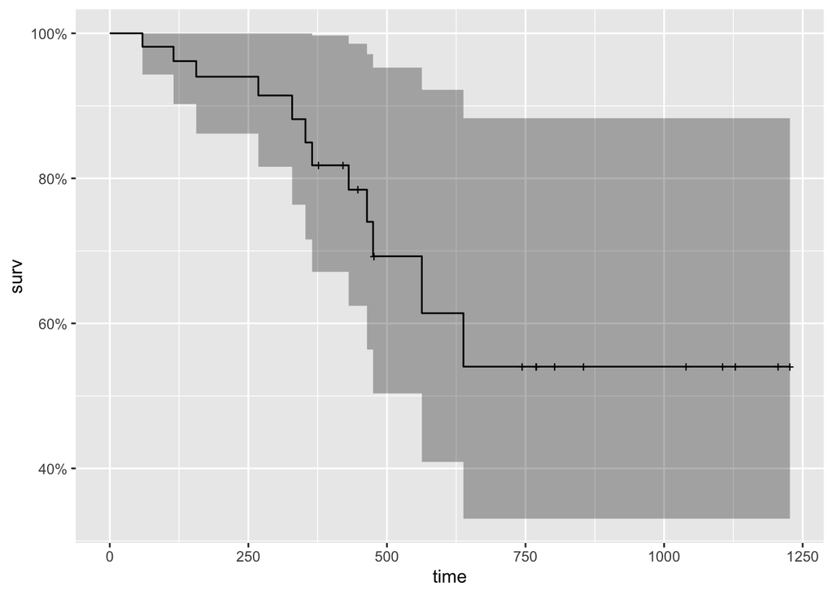

Визуально оценим вклад каждого из факторов в моделе выживаемости:

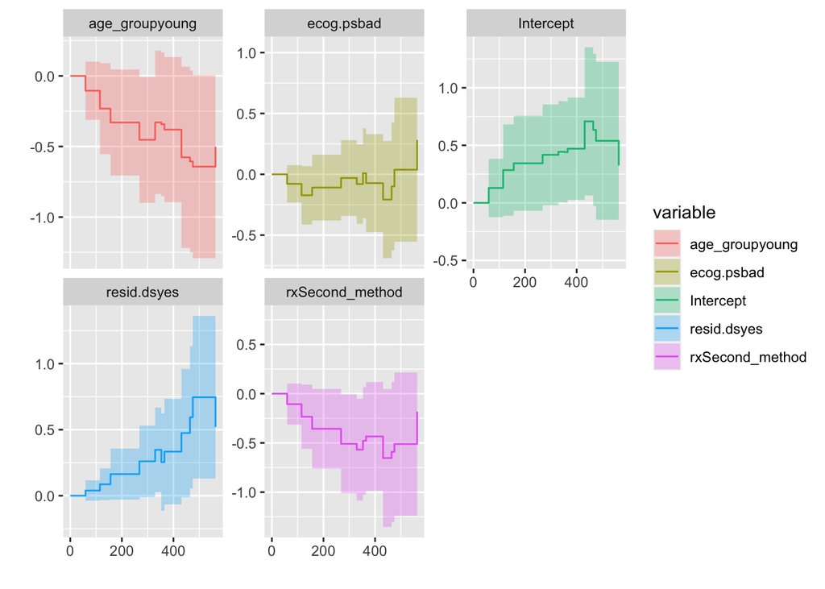

Теперь, построим график отношения рисков:

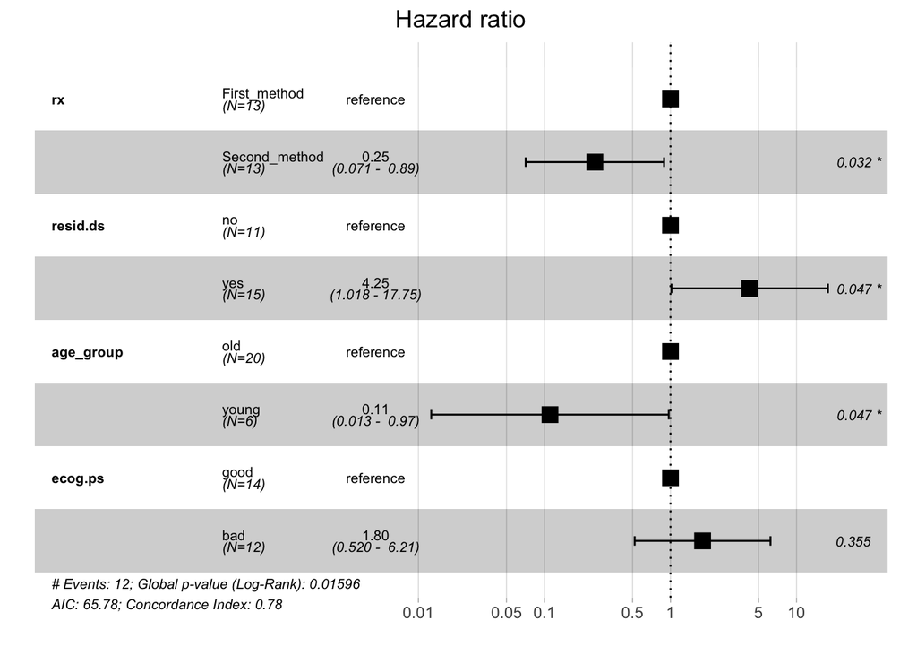

Данная схема иллюстрирует, что лечение, наличие остаточного заболевания и возраст оказывают значительное воздействие на величину риска смерти для пациента. Так, риск умереть для молодого пациента принимающего второй вариант лечения с наличием остаточного заболевания будет меньше, чем для пожилого пациента без остаточного заболевания, принимающего первый вариант лечения.